# DATA 624 Predictive Analytics (Project 2)

Simple Linear Regression

```
##      RMSE  Rsquared       MAE
## 0.7812662 0.3468832 0.6011851
```

Robust Linear Model

```
##      RMSE  Rsquared       MAE
## 0.8129427 0.2915512 0.6439884
```

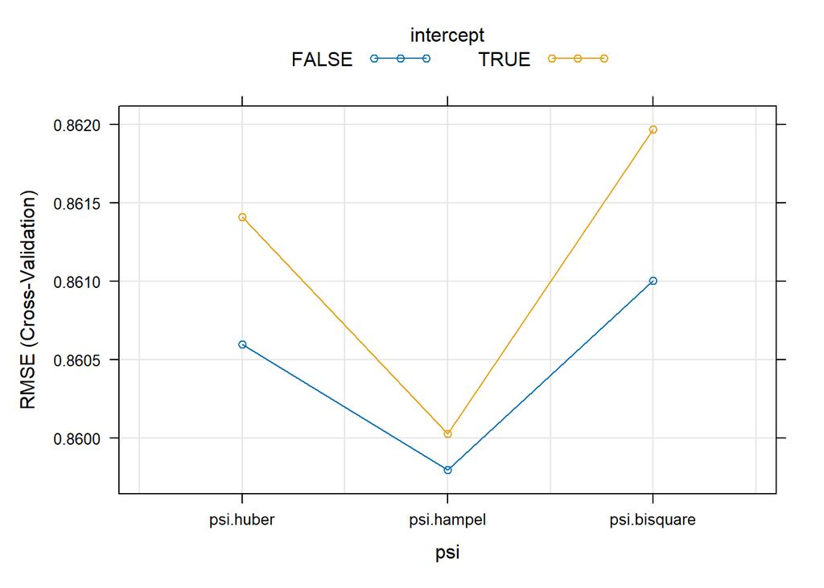

Partial Linear Squares

```
##      RMSE  Rsquared       MAE
## 0.7812578 0.3470570 0.6038144
```

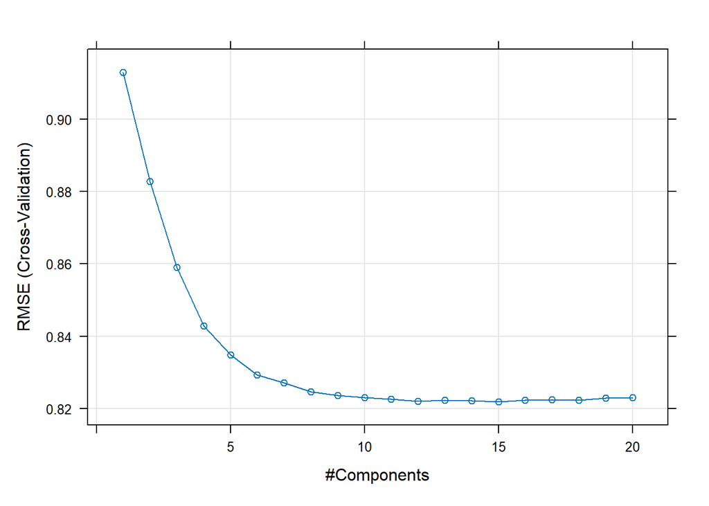

Enet Model

```
##      RMSE  Rsquared       MAE
## 0.7784749 0.3502429 0.6047150
```

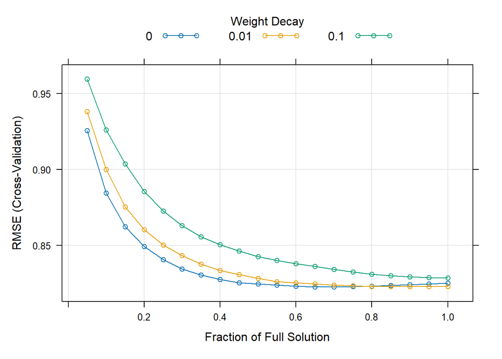

Ridge Model

```
##      RMSE  Rsquared       MAE
## 0.7795994 0.3490617 0.6028884
```

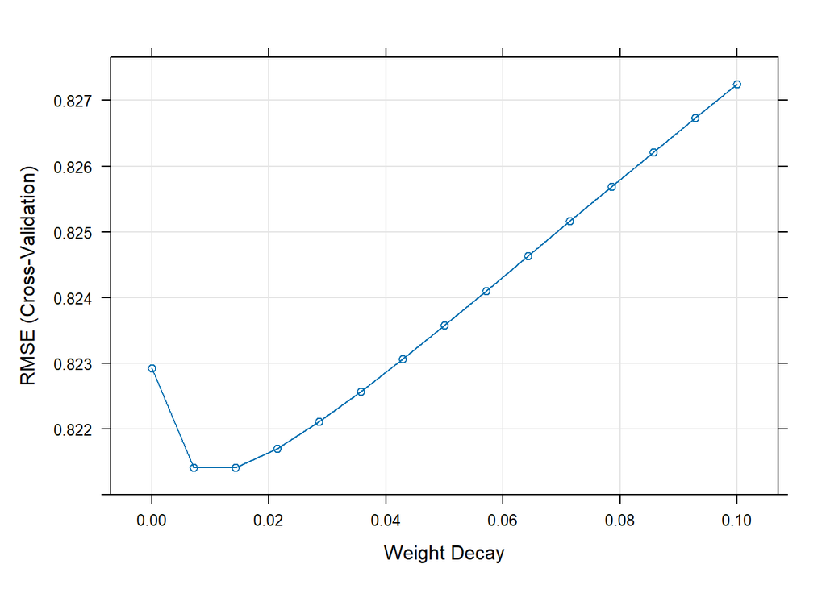

LARS

```
##      RMSE  Rsquared       MAE
## 0.7784348 0.3504221 0.6036631
```

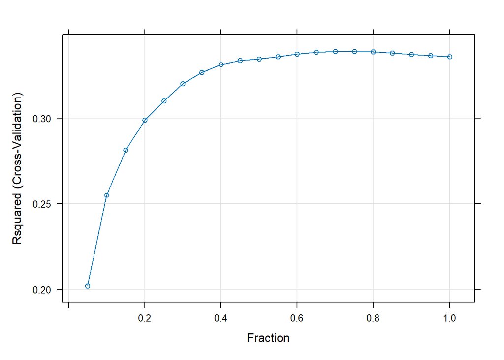

Non-Linear Models:

Split the Data 80-20 in training and testing data

KNN

```
##      RMSE  Rsquared       MAE
## 0.7943361 0.3678533 0.6059853
```

SVM

```
##      RMSE  Rsquared       MAE
## 0.7384741 0.4564360 0.5392765
```

MARS

```
##      RMSE  Rsquared       MAE
## 0.7628534 0.4136125 0.5601422
```

Random Forest

```
##      RMSE  Rsquared       MAE
## 0.6101989 0.6445020 0.4355393
```

Model Evaluation

```
##                   RMSE  Rsquared       MAE
## KNN          0.7943361 0.3678533 0.6059853
## SVM          0.7384741 0.4564360 0.5392765
## MARS         0.7628534 0.4136125 0.5601422
## RandomForest 0.6101989 0.6445020 0.4355393
## SLR          0.9201597 0.1763704 0.7047426
## RLM          0.9087564 0.1771359 0.7090285
## PLS          0.9200291 0.1770999 0.7069576
## ENET         0.9092491 0.1847612 0.6967332
## Ridge        0.9154253 0.1805659 0.7018082
## LARS         0.9111737 0.1835543 0.6975926
```

The model with the best opimal resampling and test set performance of all the models is the Random Forest model. It has the lowest RMSE (a lower RMSE predicts a better performing model) of all the models at: 0.61. It also has the highest Rsquared (a higher Rsquared indicates a better fit) of all the models at 0.64.

# Variable Importance

|  | Overall |
| --- | --- |
| carb_volume | 20.263307 |
| fill_ounces | 7.872579 |
| pc_volume | 19.647849 |
| carb_pressure | 7.311821 |
| carb_temp | 3.634613 |
| psc | 4.878180 |
| psc_fill | 1.196537 |
| psc_co2 | 1.330047 |
| mnf_flow | 51.633593 |
| carb_pressure1 | 26.185273 |

[output cut: 29 more lines]

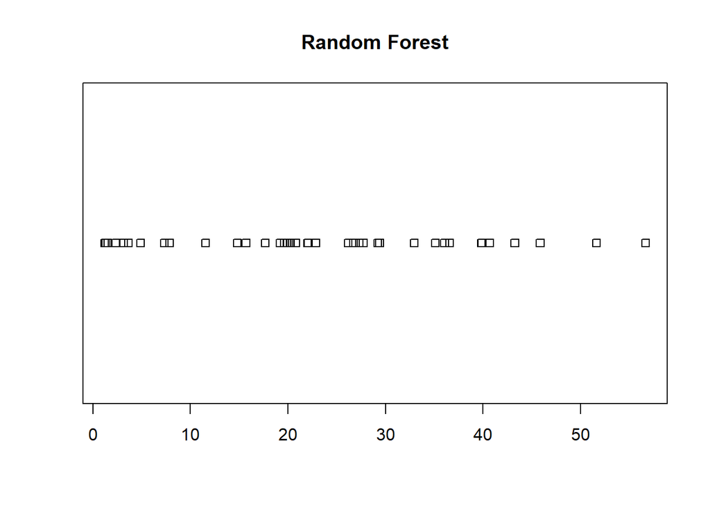

# Forecast

|  | ph2 |
| --- | --- |
| 1 | 0.1594940210017841 |
| 3 | 0.2062688846651075 |
| 7 | -0.03262216364718096 |
| 21 | -0.1680179322957281 |
| 23 | -0.3071757489657191 |
| 25 | -0.6834085217273439 |
| 36 | -0.5005366260827437 |
| 57 | -0.25237331814883 |
| 59 | -0.07187892497131551 |
| 67 | 0.020472061615626 |

[output cut: 499 more lines]

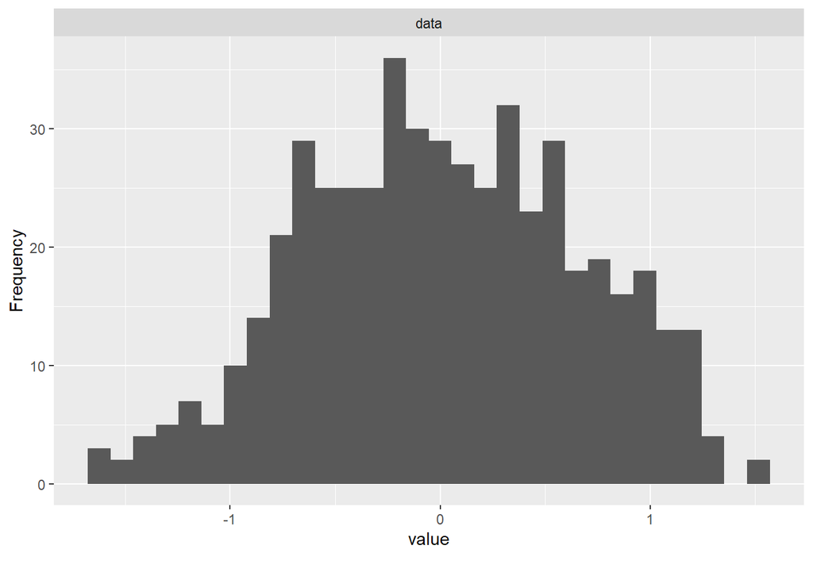

The output would indicate concentration of the predictions around around 0, largely symmetric in disttribution and concentration toward the mean, all of which suggests that our model is accurate in predicting PH values within a fairly narrow range.